# R Notebook

HappyDB is a corpus of 100,000 crowd-sourced happy moments via Amazon’s Mechanical Turk. You can read more about it on https://arxiv.org/abs/1801.07746.

Here, we explore this data set and try to answer the question, “What makes people happy?”

### Step 0 - Load all the required libraries

```r
library(tidyverse)
library(tidytext)
library(DT)
library(scales)
library(wordcloud2)
library(gridExtra)
library(ngram)
library(shiny)
library(igraph)
library(ggraph)
library(wordcloud)
library(RColorBrewer)
library(plyr)
library(Hmisc)
library(plotrix)
library(ggpubr)
library(ggfortify)
```

### Step 1 - Load the processed text data along with demographic information on contributors

We use the processed data for our analysis and combine it with the demographic information available.

```r
hm_data <- read_csv("../output/processed_moments.csv")
urlfile<-'https://raw.githubusercontent.com/rit-public/HappyDB/master/happydb/data/demographic.csv'
demo_data <- read_csv(urlfile)
urlfile2<-'https://raw.githubusercontent.com/rit-public/HappyDB/master/happydb/data/vad.csv'
vad_data <- read_csv(urlfile2)
urladr<-'https://raw.githubusercontent.com/rit-public/HappyDB/master/happydb/data/topic_dict/'
```

### Combine both the data sets and keep the required columns for analysis

We select a subset of the data that satisfies specific row conditions.

```r
hm_data <- hm_data %>%
  inner_join(demo_data, by = "wid") %>%
  select(hmid,
         wid,
         original_hm,
         gender,
         marital,
         parenthood,
         reflection_period,
         age,
         country,
         ground_truth_category,
         predicted_category,
         text) %>%
  mutate(count = sapply(hm_data$text, wordcount)) %>%
  filter(gender %in% c("m", "f")) %>%
  filter(marital %in% c("single", "married")) %>%
  filter(parenthood %in% c("n", "y")) %>%
  filter(reflection_period %in% c("24h", "3m")) %>%
  mutate(reflection_period = fct_recode(reflection_period,
                                        months_3 = "3m", hours_24 = "24h"))
```

```r
datatable(hm_data)
```

```
It seems your data is too big for client-side DataTables. You may consider server-side processing: https://rstudio.github.io/DT/server.html
```

### Create a bag of words using the text data

```r
bag_of_words <-  hm_data %>%
  unnest_tokens(word, text)
word_count <- bag_of_words %>%
  dplyr::count(word, sort = TRUE)
```

### Create bigrams using the text data

```r
hm_bigrams <- hm_data %>%
  filter(count != 1) %>%
  unnest_tokens(bigram, text, token = "ngrams", n = 2)
bigram_counts <- hm_bigrams %>%
  separate(bigram, c("word1", "word2"), sep = " ") %>%
  dplyr::count(word1, word2, sort = TRUE)
```

word cloud

```r
set.seed(1234)
# figPath = system.file("examples/t.png",package = "wordcloud2")
wordcloud2(data = word_count, shape = 'star', size = 0.6, backgroundColor = "lightsalmon" )
# wordcloud(words = word_count$word, freq = word_count$n, min.freq = 1,
#           max.words=50, random.order=FALSE, rot.per=0.15,
#           colors=brewer.pal(12, "Paired"))
```

[output not shown]

word frequency

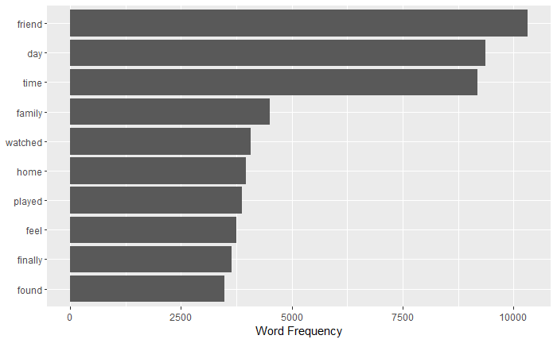

```r
word_count %>%
  slice(1:10) %>%
  mutate(word = reorder(word, n)) %>%
  ggplot(aes(word, n)) +
  geom_col() +
  xlab(NULL) +
  ylab("Word Frequency")+
  coord_flip()
```

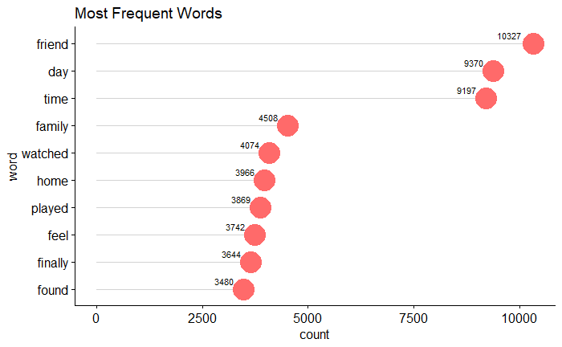

```r
#try lollipop plot
word_count_10 = data.frame(word_count %>%
  slice(1:10) %>%
  mutate(word = reorder(word, n)))
names(word_count_10)[2]="count"
ggdotchart(data=word_count_10,x="word", y="count",
           color = "indianred1",
           sorting = "descending",
           rotate = TRUE,
           dot.size = 9,
           title = "Most Frequent Words",
           label = word_count_10$count,
           font.label = list(color = "black", size = 9,
                             hjust = 1.5),
           add = "segments",
           # add.params = list(color = "lightgray", size = 1.5),
           ggtheme = theme_pubr() )
```

bigram

[figure not shown]

```r
bigram_graph <- bigram_counts %>%
  slice(1:50) %>%
  graph_from_data_frame()

  set.seed(123)

  x <- grid::arrow(type = "closed", length = unit(.1, "inches"))

  ggraph(bigram_graph, layout = "fr") +
    geom_edge_link(aes(edge_alpha = n), show.legend = FALSE,
                   arrow = x, end_cap = circle(.05, 'inches')) +
    geom_node_point(color = "lightgreen", size = 3) +
    geom_node_text(aes(label = name), repel = TRUE) +
    theme_void()
```

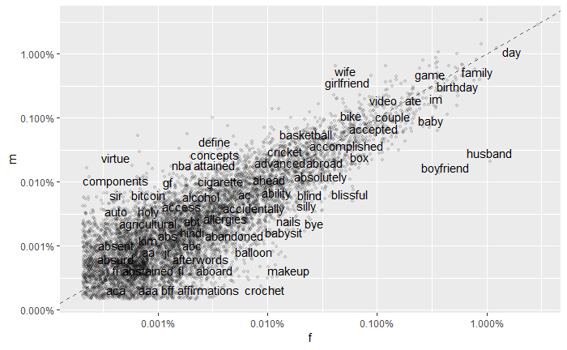

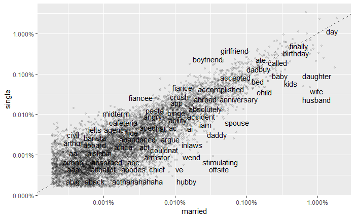

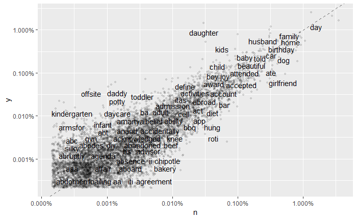

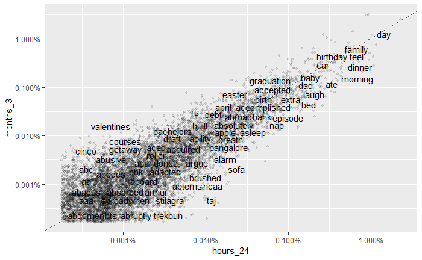

```r
comp_of_prop<-function(tmp){
  ggplot(data = tmp,
             aes_string(x = colnames(tmp)[2], y = colnames(tmp)[3]),
             color = abs(colnames(tmp)[3] - colnames(tmp)[2])) +
      geom_abline(color = "gray40", lty = 2) +
      geom_jitter(alpha = 0.1, size = 1, width = 0.3, height = 0.3) +
      geom_text(aes(label = word), check_overlap = TRUE, vjust = 1.5) +
      scale_x_log10(labels = percent_format()) +
      scale_y_log10(labels = percent_format()) +
      scale_color_gradient(limits = c(0, 0.001), low = "darkslategray4", high = "gray75") +
      theme(legend.position="none")
}

lapply(temp, FUN = comp_of_prop)
```

[figure not shown]

bigram

```
$`1`

$`2`

attr(,"class")
[1] "list"      "ggarrange"
```

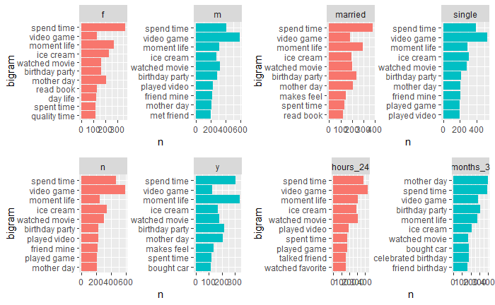

```r
ggarrange(plt[[1]],plt[[2]], plt[[3]], plt[[4]], plt, common.legend=FALSE,legend = 'right', nrow=2, ncol=2)
```

pie chart of countries

```r
countries = sort(table(demo_data$country), decreasing = TRUE)
```

```
There were 22 warnings (use warnings() to see them)
```

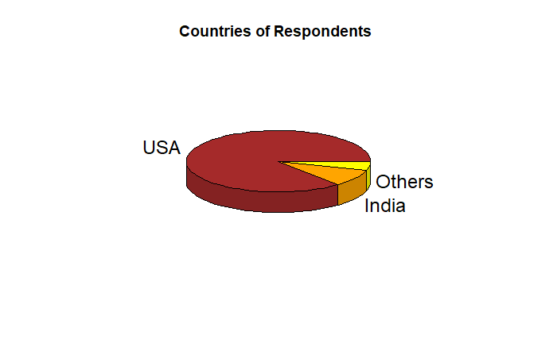

```r
main_countries = c(countries[1:2],sum(countries[-c(1,2)]))
names(main_countries)=c("USA", "India","Others")
main_countries = round(main_countries/sum(main_countries), digits = 3)
#
# lp<-pie3D(main_countries,radius=0.9,labels=paste(names(main_countries),":",main_countries,sep=""),  main="3D Pie Chart of Countries")
# lp=lp+0.4
pie3D(main_countries,labels=paste(names(main_countries),sep=""),radius = 0.9, main="Countries of Respondents ",col=c("brown","orange","yellow"), labelcex = 1.5)
```

```r
# pieval<-c(2,4,6,8)
#  pielabels<-
#   c("We hate\n pies","We oppose\n  pies","We don't\n  care","We just love pies")
#  # grab the radial positions of the labels
# lp<-pie3D(pieval,radius=0.9,labels=pielabels,explode=0.1,main="3D PIE OPINIONS")
#  # lengthen the last label and move it to the left
#  pielabels[4]<-"We cannot survive without our pies"
#  lp[4]<-4.8
#  # specify some new colors
#  pie3D(pieval,radius=0.9,labels=pielabels,explode=0.1,main="3D PIE OPINIONS",
#   col=c("brown","#ddaa00","pink","#dd00dd"),labelpos=lp)
```

specify ordinal number of indians

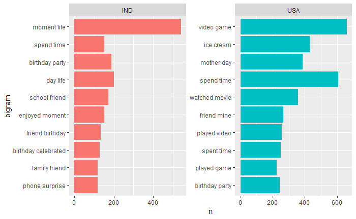

```r
temp4 <- hm_bigrams %>%
  dplyr::count(country, bigram, sort = TRUE) %>%
  group_by(country) %>%
  filter(country %in% c("USA", "IND"))%>%
  top_n(10) %>%
  ungroup() %>%
  mutate(bigram = reorder(bigram, n))
ggplot(data = temp4,
       aes(bigram, n, fill = country)) +
  geom_col(show.legend = FALSE) +
  facet_wrap(as.formula(paste("~", "country")), ncol = 2, scales = "free") +
  coord_flip()
```

add predicted category and vad data to the hm_data

```r
hm_data <- hm_data %>%
  inner_join(vad_data, by = "hmid") %>%
  select(hmid,
         wid,
         original_hm,
         gender,
         marital,
         parenthood,
         reflection_period,
         age,
         country,
         ground_truth_category,
         predicted_category,
         text,
         valency,
         dominance,
         arousal)
```

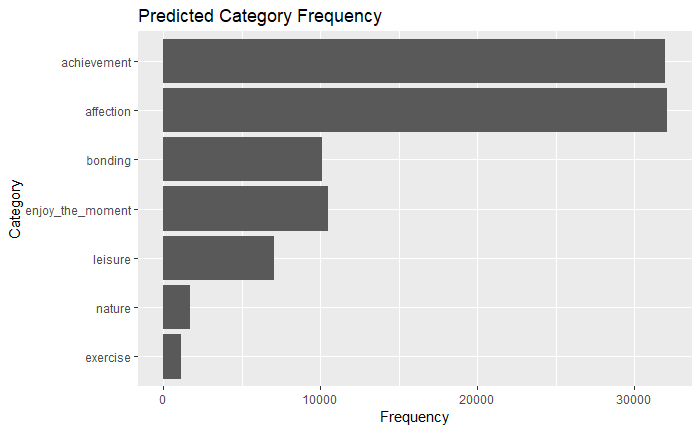

```r
pred_cat = hm_data[,c(4:7,9,11)]
pred_cat$predicted_category = factor(hm_data$predicted_category,
                                     levels = rev(c("achievement", "affection", "bonding",
                                                "enjoy_the_moment","leisure","nature","exercise")))
ggplot(data = pred_cat)+
  geom_bar(aes(x=predicted_category))+
  # facet_wrap(as.formula(paste("~", "reflection_period")), ncol = 2, scales = "free")+
  coord_flip()+
  labs(title = "Predicted Category Frequency", x = "Category", y = "Frequency")
```

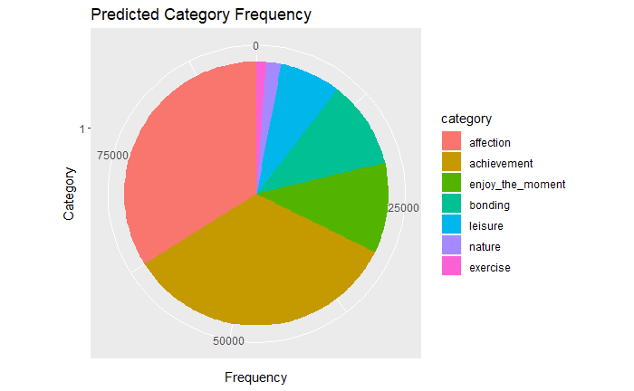

```r
  # theme(axis.text.x = element_text(angle = 60, hjust = 1))
pred_cat_table = as.data.frame(sort(table(pred_cat$predicted_category), decreasing = TRUE))
names(pred_cat_table)[1]="category"
ggplot(data = pred_cat_table, aes(x=factor(1), y=Freq, fill=category))+
  geom_bar(width=1, stat="identity")+
  # facet_wrap(as.formula(paste("~", "reflection_period")), ncol = 2, scales = "free")+
  coord_polar(theta = "y")+
  labs(title = "Predicted Category Frequency", x = "Category", y = "Frequency")
```

```r
  # theme(axis.text.x = element_text(angle = 60, hjust = 1))
```

try pie chart!

```r
# atrs <- c("gender", "marital", "parenthood", "reflection_period")
#
# for(atr in atrs){
#   ggplot(data = pro_data)+
#   geom_bar(aes(x=predicted_category, fill = !!as.symbol(atr)))+
#   facet_wrap(as.formula(paste("~", atr)), ncol = 2, scales = "free")+
#   labs(title = "Predicted Category Frequency", x = "Category", y = "Frequency")+
#   theme(axis.text.x = element_text(angle = 60, hjust = 1))
# }
#
# comp_cat<-function(tmp){
#   ggplot(data = pred_cat)+
#   geom_bar(aes(x=predicted_category, fill=!!as.symbol(tmp)))+
#   facet_wrap(as.formula(paste("~", tmp)), ncol = 2, scales = "free")+
#   coord_flip()+
#   labs(title = "Predicted Category", x = "Category", y = "Frequency")
#   #theme(axis.text.x = element_text(angle = 60, hjust = 1))
# }
# lapply(as.list(atrs),FUN = comp_cat)
#
# #as.matrix(atrs,ncol=1,nrow=4)
#
# cat_box<-function(tmp){
#   ggplot(data = pred_cat)+
#   geom_bar(aes(x=predicted_category, fill=!!as.symbol(tmp)),position = "dodge", stat="identity")
#   #facet_wrap(as.formula(paste("~", tmp)), ncol = 2, scales = "free")+
#   # coord_flip()+
#   # labs(title = "Predicted Category", x = "Category", y = "Frequency")
#   #theme(axis.text.x = element_text(angle = 60, hjust = 1))
# }
# # lapply(as.list(atrs),FUN = cat_box)
#
#
# # comment out above
atrs <- c("gender", "marital", "parenthood", "reflection_period")
temp0 = list()
# for(i in 1:length(atrs)){
#   temp0[[i]] <- split(pred_cat, f = pred_cat[,i])
# }
#
# pred_cat_ui = pred_cat%>%
#   select(country,
#          predicted_category)%>%
#   filter(country %in% c("USA", "IND"))
#
# temp0[[5]] <- split(pred_cat_ui, f = pred_cat_ui[,1])
#
# atrs = c(atrs, "country")
# names(temp0) = atrs
sql_cat = list()
for (i in 1:length(atrs)){
  sql_cat[[i]] = pred_cat%>%
                   dplyr::count(!!as.symbol(atrs[i]),predicted_category)%>%
                   group_by(!!as.symbol(atrs[i]),predicted_category)
}
sql_cat[[5]] = pred_cat%>%
  dplyr::count(country,predicted_category)%>%
  group_by(country,predicted_category)%>%
  filter(country %in% c("USA","IND"))
atrs[5]="country"
names(sql_cat)=atrs
divi <-function(vec,df){
  vec1 = as.vector(vec)
  if (as.character(vec1[1])==as.character(df[1,1])){
    vec1[3]=as.numeric(vec1[3])/as.numeric(df[1,2])
  }
  else{
    vec1[3]=as.numeric(vec1[3])/as.numeric(df[2,2])
  }
  return(vec1[3])
}
cnt_to_prop<-function(df){
  df = data.frame(df)
  df_sum = df%>%
    group_by(!!as.symbol(names(df)[1]))%>%
    dplyr::summarise(total = sum(n, na.rm = TRUE))
  df_sum = data.frame(df_sum)
  props = round(as.numeric(apply(df,1,divi,df_sum)),digits = 4)
  df[,3] = props
  names(df)[3]="proportion"
  return(df)
}
gen = data.frame(sql_cat[[1]])
#try
ttt = data.frame(data.frame(sql_cat[[1]])%>%
    group_by(gender)%>%
    dplyr::summarise(total = sum(n)))

cnt_to_prop(data.frame(sql_cat[[1]]))
```

```
   gender predicted_category proportion
1       f           exercise     0.0089
2       f             nature     0.0209
3       f            leisure     0.0619
4       f   enjoy_the_moment     0.1026
5       f            bonding     0.0995
6       f          affection     0.4096
7       f        achievement     0.2966
8       m           exercise     0.0143
9       m             nature     0.0161
10      m            leisure     0.0838
11      m   enjoy_the_moment     0.1165
12      m            bonding     0.1124
13      m          affection     0.2905
14      m        achievement     0.3663
```

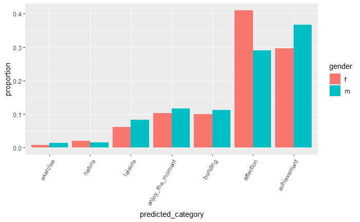

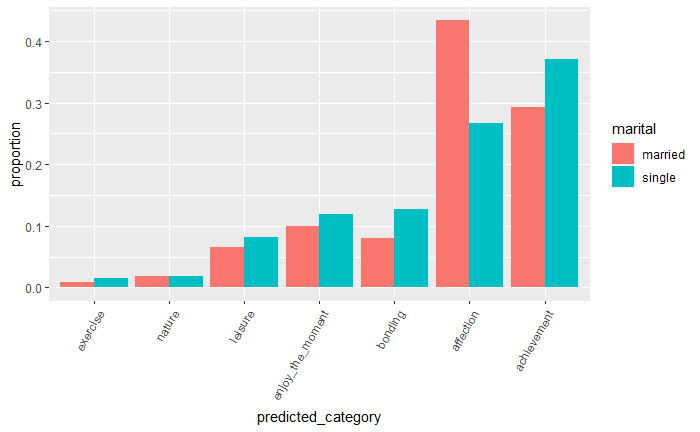

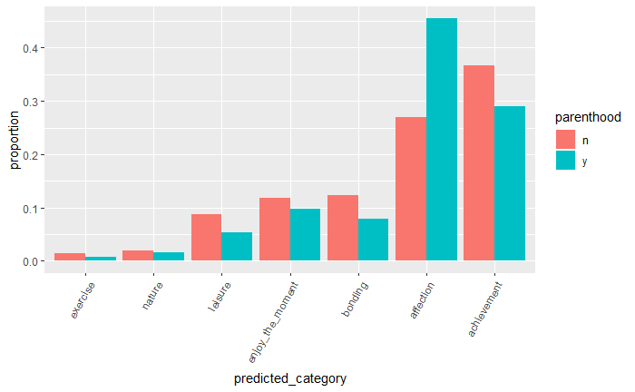

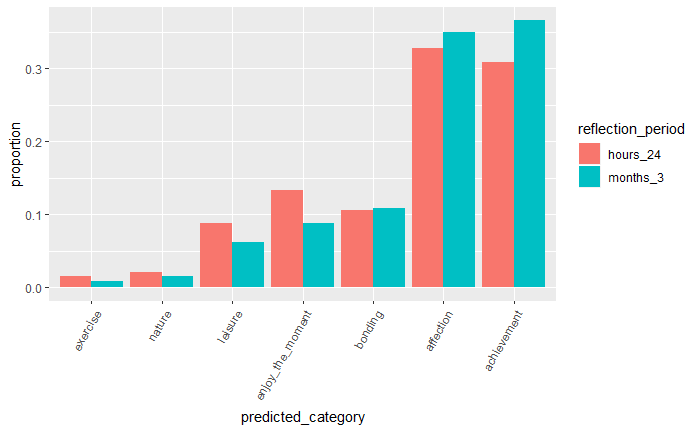

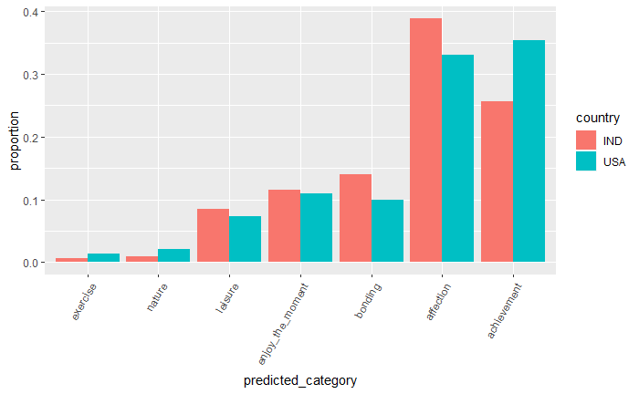

```r
    #summarise(total = sum(n))
#!!as.symbol(names(sql_cat[[1]])[1])
bi_cat<-function(df){
  df = cnt_to_prop(df)
  ggplot(data=df, aes(x=!!as.symbol(names(df)[2]),y=!!as.symbol(names(df)[3])))+
    geom_bar(aes(fill=!!as.symbol(names(df)[1])), position = "dodge", stat="identity")+
    theme(axis.text.x = element_text(angle = 60, hjust = 1))
}
lapply(sql_cat, FUN = bi_cat )
```

try compare in the same graph

```r
# pred_cat_ui = pred_cat%>%
#   select(country,
#          predicted_category)%>%
#   filter(country %in% c("USA", "IND"))
#
# ggplot(data = pred_cat_ui)+
#   geom_bar(aes(x=predicted_category, fill=country))+
#   facet_wrap(as.formula(paste("~", "country")), ncol = 2, scales = "free")+
#   coord_flip()+
#   labs(title = "Predicted Category", x = "Category", y = "Frequency")
#   # theme(axis.text.x = element_text(angle = 60, hjust = 1))
```

dictionary

# try out dictionary count

```r
lexicon = c("greatest" ,"glory" , "rising")
sen = "Our greatest greatest glory is not in never falling, but in rising every time we fall #confucius #entrepreneurship"
wordss = strsplit(sen," ")
sum(wordss[[1]] %in% lexicon) #returns the number of words that matches lexicon
```

```
[1] 4
```

```r
sum(wd %in% dict_list[[1]][,1])
```

[output not shown]

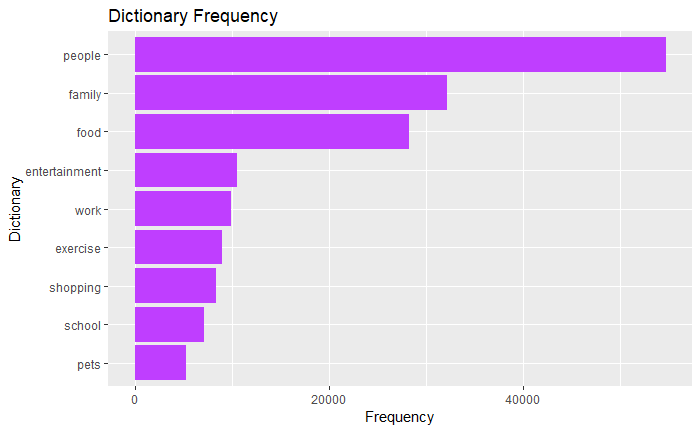

```r
urladr<-'https://raw.githubusercontent.com/rit-public/HappyDB/master/happydb/data/topic_dict/'
dict_vec = c("entertainment", "exercise", "family", "food", "people", "pets","school", "shopping", "work")
load_dict<-function(dict){
  return(read.csv(paste(urladr,dict,"-dict.csv", sep = ""),header = FALSE))
}
# matrix(dict_vec,nrow=length(dict_vec),ncol=1)
dict_list = plyr::alply(matrix(dict_vec,nrow=length(dict_vec),ncol=1),1,load_dict)
names(dict_list) = dict_vec
txt = as.vector(hm_data$text)
txt = paste(txt, collapse = " ")
wd = strsplit(txt, split = " ")[[1]]
txt_table = table(wd)
txt_df = as.data.frame(txt_table)
count_key<-function(key, cnt, txt_df){
  if (key %in% txt_df[,1]){
    return(txt_df[which(txt_df[,1]==key),2])
  }
  else{
    return(0)
  }
}
count_dict<-function(df, txt_df){
  cnt = 0
  cnt_vec = apply(as.matrix(df), 1, count_key, cnt, txt_df)
  return(sum(cnt_vec))
}
dict_count = sort(sapply(dict_list, FUN = count_dict, txt_df), decreasing = TRUE)

# dict_count = sort(sapply(dict_list, FUN = count_dict, txt_df), decreasing = TRUE)
dict_expand = as.data.frame(rep(names(dict_count),dict_count))
names(dict_expand)="words"
dict_expand$words <- factor(dict_expand$words, levels = rev(names(dict_count)))
ggplot(data = dict_expand)+
  geom_bar(aes(x=words),fill = "darkorchid1")+
  labs(x="Dictionary", y="Frequency", title = "Dictionary Frequency")+
  coord_flip()
```

try sth similar to pie chart 1.lollipop chart: ggdotchart

```r
atrs <- c("gender", "marital", "parenthood", "reflection_period")
temp5 = list()
for(i in 1:length(atrs)){
  temp5[[i]] <- bag_of_words %>%
      dplyr::count(!!as.symbol(atrs[i]),word) %>%
      group_by(!!as.symbol(atrs[i])) %>%
      mutate(cnt = n) %>%
      select(-n)
      # spread(!!as.symbol(atrs[i]),value)
}

temp5[[5]] <- bag_of_words%>%
      dplyr::count(country,word) %>%
      group_by(country) %>%
      filter(country %in% c("USA","IND"))%>%
      mutate(cnt = n) %>%
      select(-n)

atrs = c(atrs, "country")
names(temp5) = atrs
#temp5 is a list of 4 dataframes counting words in each group

#
# txt_table = table(wd)
# txt_df = as.data.frame(txt_table)
#
# count_key<-function(key, cnt, txt_df){
#   if (key %in% txt_df[,1]){
#     return(txt_df[which(txt_df[,1]==key),2])
#   }
#   else{
#     return(0)
#   }
# }
#
# count_dict<-function(df){
#   cnt = 0
#   cnt_vec = apply(as.matrix(df), 1, count_key, cnt, txt_df)
#   return(sum(cnt_vec))
# }


pre_split<-function(df){
  return(split(df[,2:3],f=df[,1]))
}
#split a dataframe into a list of 2 dataframes

atr_lists=lapply(temp5, FUN = pre_split)
#atr_lists is a list of 4 lists of 2 dataframes counting words in each group


comp_dict<-function(df){
  txt_df = df
  dict_cnt = sort(sapply(dict_list, FUN = count_dict, as.data.frame(txt_df)), decreasing = TRUE)
  return(dict_cnt)
}

# co_dict<-function(df){
#   txt_df = df
#   dict_cnt = sort(sapply(dict_list, FUN = c_dict, as.data.frame(txt_df)), decreasing = TRUE)
#   return(dict_cnt)
# }

#trial
# comp_dict(atr_lists[[4]][[1]])

sublist<-function(lst){
  dict_cnt_l = lapply(lst, FUN = comp_dict)
  return(dict_cnt_l)
}
#
# slist<-function(lst){
#   dict_cnt_l = lapply(lst, FUN = co_dict)
#   return(dict_cnt_l)
# }
#
# co_output = lapply(atr_lists, FUN = slist)

#lists of 8 tables:same results!
comp_output = lapply(atr_lists, FUN = sublist)

tblst_to_df<-function(tblst){
  nm= NA

  df1=as.data.frame(rep(names(tblst[[1]]),tblst[[1]]))
  names(df1)="dicts"
  df1$gp = names(tblst)[1]
  df2=as.data.frame(rep(names(tblst[[2]]),tblst[[2]]))
  names(df2)="dicts"
  df2$gp = names(tblst)[2]
  df = rbind(df1, df2)

  if(names(tblst)[1]=="f"){
    nm=atrs[1]
  }
  else if(names(tblst)[1]=="married"){
    nm=atrs[2]
  }
  else if(names(tblst)[1]=="n"){
    nm=atrs[3]
  }
  else if(names(tblst)[1]=="hours_24"){
    nm=atrs[4]
  }
  else if(names(tblst)[1]=="IND"){
    nm=atrs[5]
  }

  names(df)[2]=nm
  return(df)
}

#for each of the 4 lists in comp_output
comp_dict_plot<-function(lst2){
  df_mix = tblst_to_df(lst2)
  df_mix$dicts = factor(df_mix$dicts,levels = rev(names(comp_output[[1]][[1]])))

  ggplot(data = df_mix)+
  geom_bar(aes(x=dicts, fill=!!as.symbol(names(df_mix)[2])))+
  facet_wrap(as.formula(paste("~", names(df_mix)[2])), ncol = 2, scales = "free")+
  coord_flip()+
  labs(title = "Frequency of Words in Each Topic", x = "Dictionary", y = "Frequency")+
  scale_fill_manual(values=c("#CC6666", "#66CC99"))
  # theme(axis.text.x = element_text(angle = 60, hjust = 1))
}

lapply(comp_output, FUN = comp_dict_plot)
# length(plt)
#
# ggarrange(plt[[1]],plt[[2]], plt[[3]], plt[[4]], plt[[5]],common.legend=FALSE,legend = 'right', nrow=5)
```

[output not shown]

try another form

vad valence (the pleasantness of a stimulus): arousal (the intensity of emotion provoked by a stimulus), dominance (the degree of control exerted by a stimulus)

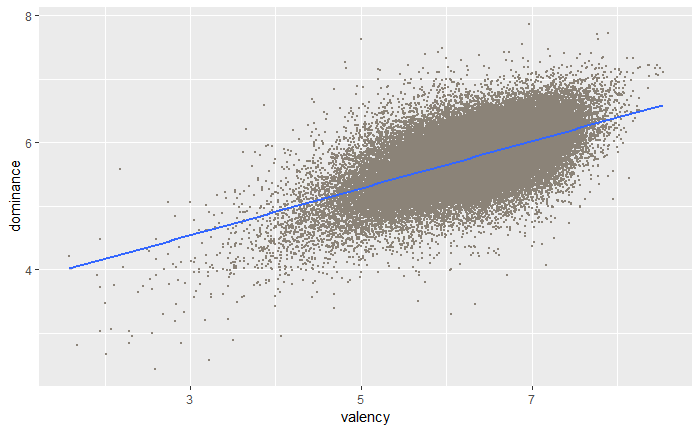

```r
ggplot(data=hm_data)+
  geom_jitter(aes(x=valency, y=dominance), size =0.1, color = "antiquewhite4")+
  stat_smooth(aes(x=valency, y=dominance),method = "lm", formula = y ~ x, size = 1)
```

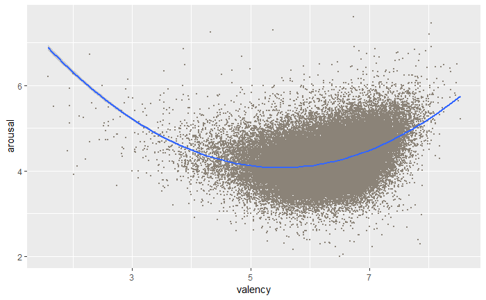

```r
ggplot(data=hm_data)+
  geom_jitter(aes(x=valency, y=arousal), size =0.1, color = "antiquewhite4")+
  stat_smooth(aes(x=valency, y=arousal),method = "lm", formula = y ~ x + I(x^2), size = 1)
```

```r
# reg = lm(arousal~valency+I((valency)^2), data = hm_data)
# summary(reg)
```

split arousal~valency into high-low 4 groups and anayze attributes ??ignore

```r
# val_avg=mean(hm_data$valency,na.rm = TRUE)
# aro_avg=mean(hm_data$arousal,na.rm = TRUE)
# ggplot(data=hm_data)+
#   geom_point(aes(x=valency, y=arousal), size =0.1)+
#   geom_vline(xintercept = val_avg, color = "red")+
#   geom_hline(yintercept = aro_avg, color = "red")
```

? explore why there is a quadratic trend

? why happy moments expressed whith low valency one man’s meat is another man’s poison low_val: ppl in adversity happiness is relative

?high valency: universal happiness?

```r
low_val = head(hm_data[order(hm_data$valency,decreasing = FALSE),]$original_hm,10)
low_val
```

```
 [1] "I planned out my suicide."
 [2] "I got recovered from the disease i had"
 [3] "getting out of jail"
 [4] "i was released from jail."
 [5] "Paid off all my bills and caught up on all my debt"
 [6] "I paid off all my debt"
 [7] "I paid off some of my debt today"
 [8] "I got over my illness"
 [9] "I paid off my debt."
[10] "finished paying off a looming debt that i had been struggling with for several years."
```

```r
# happiness arise from pain
high_val=  head(hm_data[order(hm_data$valency,decreasing = TRUE),]$original_hm,10)
high_val
```

```
 [1] "I found out I was going to florida for vacation."
 [2] "I went on vacation in Rome"
 [3] "We are going to Goa for our vacation. Tickets confirmed."
 [4] "I planned out my next vacation."
 [5] "I remembered that I'm on vacation in a few weeks."
 [6] "Planned a vacation to Philadelphia"
 [7] "Booked a vacation with friends."
 [8] "It was when we went to Florida for vacation."
 [9] "I went on vacation to Santiago."
[10] "We were heading out on vacation with some friends."
```

```r
#real happiness
low_aro = head(hm_data[order(hm_data$arousal,decreasing = FALSE),]$original_hm,10)
low_aro
```

```
 [1] "My kitty fell asleep in my arms."
 [2] "I fell asleep next to her."
 [3] "I went to starbucks and ordered a tea I hadn't tried before and I actually liked it"
 [4] "I bought Boba Tea"
 [5] "Made some tea."
 [6] "I level up in games"
 [7] "I completed another level of Spanish on Duolingo."
 [8] "I went whitewater rafting in North Carolina."
 [9] "I went zip-lining in North Carolina."
[10] "I met Lebron James and he gave t-shirt"
```

```r
#
# mid_val_high_aro = (hm_data%>%
#   filter(arousal>6)%>%
#   filter(valency<5.1 & valency>4.8))$original_hm
# mid_val_high_aro
```

not very interesting

```r
hm_vad = hm_data[!is.na(hm_data$valency) & !is.na(hm_data$arousal),]
coord = list()
coord[[1]] = hm_vad[hm_vad$valency>val_avg & hm_vad$arousal>aro_avg,]
coord[[2]] = hm_vad[hm_vad$valency<val_avg & hm_vad$arousal>aro_avg,]
coord[[3]] = hm_vad[hm_vad$valency<val_avg & hm_vad$arousal<aro_avg,]
coord[[4]] = hm_vad[hm_vad$valency>val_avg & hm_vad$arousal<aro_avg,]
est<-function(df){
  gender_prop = sum(df$gender=="m", na.rm = TRUE)/sum(df$gender=="f", na.rm = TRUE)
  marital_prop = sum(df$marital=="single", na.rm = TRUE)/sum(df$marital=="married", na.rm = TRUE)
  parenthood_prop = sum(df$parenthood=="n", na.rm = TRUE)/sum(df$parenthood=="y", na.rm = TRUE)
  reflection_prop= sum(df$reflection_period=="hours_24",na.rm=TRUE)/sum(df$reflection_period=="months_3", na.rm = TRUE)
  return(c(gender_prop,marital_prop,parenthood_prop,reflection_prop))
}
coord_prop = lapply(coord, FUN = est)
comp_coord = matrix(NA,ncol=4,nrow=4)
for(i in 1:length(coord_prop)){
  comp_coord[i,] = coord_prop[[i]]
}
colnames(comp_coord) = atrs[1:4]
comp_coord = as.data.frame(comp_coord)
comp_coord
```

```
    gender  marital parenthood reflection_period
1 1.347224 1.230880   1.494263         0.9143454
2 1.609933 1.403092   1.698648         0.8640495
3 1.545036 1.366085   1.722174         1.0003547
4 1.320933 1.268503   1.709147         1.1571195
```

```r
est(hm_vad)
```

```
[1] 1.4369619 1.3054081 1.6398813 0.9819837
```

[figure not shown]

# not interesting

```r
urlfile3<-'https://raw.githubusercontent.com/rit-public/HappyDB/master/happydb/data/senselabel.csv'
sense_data <- read_csv(urlfile3)
```

boxplot

```r
Degrees <- factor(ranSamples$DegLevel, levels = unique(ranSamples$DegLevel))
```

[output not shown]

[figure not shown]

~arousal try violin plot try save violin to age~vad 5 violins can comment out

```r
# comp_violin<-function(chrct){
#   ggplot(hm_data,aes(x=!!as.symbol(chrct), y = arousal))+
#     geom_violin(aes(fill=!!as.symbol(chrct)))+
#     ggtitle(paste("Comparing Valency between ", capitalize(chrct)))
# }
#
# apply(atrs_matrix,1,comp_violin)
#
# ggplot(country_vad,aes(x=country, y = arousal))+
#  geom_violin(aes(fill = country))
```

```r
vad_age = data.frame(hm_data)[,-c(13,14,15)]%>%
  inner_join(km_vad, by="hmid")%>%
  select(hmid,
         age,
         valency,
         arousal,
         dominance,
         subjective_group)
vad_age$age = as.numeric(vad_age$age)
```

```
NAs introduced by coercion
```

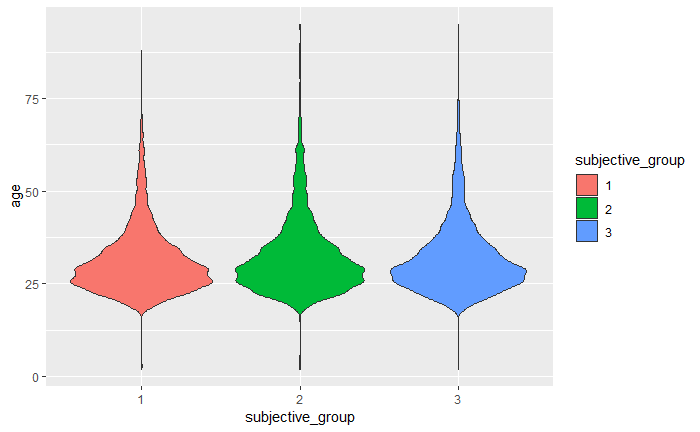

```r
vad_age = stats::na.omit(vad_age)
vad_age = vad_age[vad_age$age < 100,]
ggplot(vad_age,aes(x=subjective_group, y = age))+
 geom_violin(aes(fill = subjective_group))
```

kmeans eg

```r
# require(graphics)
#
# # a 2-dimensional example
# x <- rbind(matrix(rnorm(100, sd = 0.3), ncol = 2),
#            matrix(rnorm(100, mean = 1, sd = 0.3), ncol = 2))
# colnames(x) <- c("x", "y")
# (cl <- kmeans(x, 2))
# plot(x, col = cl$cluster)
# points(cl$centers, col = 1:2, pch = 8, cex = 2)
#
# # sum of squares
# ss <- function(x) sum(scale(x, scale = FALSE)^2)
#
# ## cluster centers "fitted" to each obs.:
# fitted.x <- fitted(cl);  head(fitted.x)
# resid.x <- x - fitted(cl)
#
# ## Equalities : ----------------------------------
# cbind(cl[c("betweenss", "tot.withinss", "totss")], # the same two columns
#          c(ss(fitted.x), ss(resid.x),    ss(x)))
# stopifnot(all.equal(cl$ totss,        ss(x)),
#     all.equal(cl$ tot.withinss, ss(resid.x)),
#     ## these three are the same:
#     all.equal(cl$ betweenss,    ss(fitted.x)),
#     all.equal(cl$ betweenss, cl$totss - cl$tot.withinss),
#     ## and hence also
#     all.equal(ss(x), ss(fitted.x) + ss(resid.x))
#     )
#
# kmeans(x,1)$withinss # trivial one-cluster, (its W.SS == ss(x))
#
# ## random starts do help here with too many clusters
# ## (and are often recommended anyway!):
# (cl <- kmeans(x, 5, nstart = 25))
# plot(x, col = cl$cluster)
# points(cl$centers, col = 1:5, pch = 8)
# plot(km_vad[,2:3], col = fit$cluster)
# head(vad)
```

[figure not shown]

```r
vad_bag = data.frame(bag_of_words)%>%
  inner_join(km_vad, by = "hmid")%>%
  select(hmid, word, subjective_group)
wc_vad = data.frame(vad_bag%>%
  group_by(subjective_group)%>%
  dplyr::count(word))
head(wc_vad)
```

```
  subjective_group      word n
1                1       aam 1
2                1   aashwin 2
3                1    abacus 1
4                1 abandoned 5
5                1      abby 2
6                1   ability 9
```

```r
class(wc_vad)
```

```
[1] "data.frame"
```

```r
wc_vad_lists = pre_split(wc_vad)
length(wc_vad_lists)
```

```
[1] 3
```

```r
head(wc_vad_lists)
```

```
$`1`
                                   word    n
1                                   aam    1
2                               aashwin    2
3                                abacus    1
4                             abandoned    5
5                                  abby    2
6                               ability    9
7                                aboard    3
8                                abroad   31
9                                   abs    2
10                              absence    1
11                           absolutely   51
12                             absorbed    1
13                            abstained    1
```

[output cut: 1496 more lines]

```r
op = sublist(wc_vad_lists)
# op
op_df_lst = lapply(op, as.data.frame)
# op_df_lst
op_df_lst[[1]]$dicts = row.names(op_df_lst[[1]])
 op_df_lst
```

```
$`1`
              X[[i]]         dicts
people         19871        people
family         12000        family
food            9287          food
entertainment   4016 entertainment
shopping        2794      shopping
exercise        2468      exercise
work            2161          work
pets            2126          pets
school          1385        school

$`2`
              X[[i]]
people         27946
family         17124
food           16949
entertainment   5533
exercise        4781
shopping        4230
work            4086
school          3393
pets            2402

$`3`
              X[[i]]
people          6646
work            3628
family          2967
school          2380
food            1932
exercise        1722
shopping        1219
entertainment    977
pets             695
```

```r
op_df = NULL
for (i in 1:3){
  op_df_lst[[i]]$dicts = row.names(op_df_lst[[i]])
  op_df_lst[[i]]$group = i
  names(op_df_lst[[i]])[1]="proportion"
  op_df_lst[[i]]$proportion = round(op_df_lst[[i]]$proportion/sum(op_df_lst[[i]]$proportion),digits = 4)
  op_df = rbind(op_df,op_df_lst[[i]])
}
op_df_lst
```

```
$`1`
              proportion         dicts group
people            0.3542        people     1
family            0.2139        family     1
food              0.1655          food     1
entertainment     0.0716 entertainment     1
shopping          0.0498      shopping     1
exercise          0.0440      exercise     1
work              0.0385          work     1
pets              0.0379          pets     1
school            0.0247        school     1

$`2`
              proportion         dicts group
people            0.3233        people     2
family            0.1981        family     2
food              0.1961          food     2
entertainment     0.0640 entertainment     2
exercise          0.0553      exercise     2
shopping          0.0489      shopping     2
work              0.0473          work     2
school            0.0393        school     2
pets              0.0278          pets     2

$`3`
              proportion         dicts group
people            0.2998        people     3
work              0.1637          work     3
family            0.1339        family     3
school            0.1074        school     3
food              0.0872          food     3
exercise          0.0777      exercise     3
shopping          0.0550      shopping     3
entertainment     0.0441 entertainment     3
pets              0.0314          pets     3
```

```r
op_df
```

```
               proportion         dicts group
people             0.3542        people     1
family             0.2139        family     1
food               0.1655          food     1
entertainment      0.0716 entertainment     1
shopping           0.0498      shopping     1
exercise           0.0440      exercise     1
work               0.0385          work     1
pets               0.0379          pets     1
school             0.0247        school     1
people1            0.3233        people     2
family1            0.1981        family     2
food1              0.1961          food     2
entertainment1     0.0640 entertainment     2
exercise1          0.0553      exercise     2
shopping1          0.0489      shopping     2
work1              0.0473          work     2
school1            0.0393        school     2
pets1              0.0278          pets     2
people2            0.2998        people     3
work2              0.1637          work     3
family2            0.1339        family     3
school2            0.1074        school     3
food2              0.0872          food     3
exercise2          0.0777      exercise     3
shopping2          0.0550      shopping     3
entertainment2     0.0441 entertainment     3
pets2              0.0314          pets     3
```

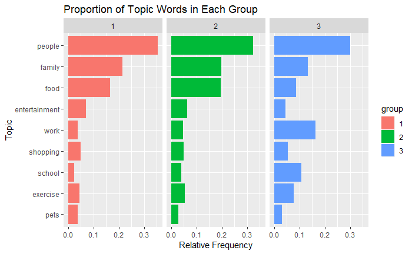

```r
op_df$group=as.factor(op_df$group)
op_df$dicts = factor(op_df$dicts,levels = rev(names(comp_output[[1]][[1]])))
  # df_op = tblst_to_df(op)
  # names(df_op)[2] = "group"
  # df_op$dicts = factor(df_op$dicts,levels = rev(names(comp_output[[1]][[1]])))
  #
  ggplot(data = op_df,aes(x=dicts,y=proportion, fill=group))+
  geom_bar(stat = "identity")+
  facet_wrap(as.formula("~group"), ncol = 3)+
  coord_flip()+
  labs(title = "Proportion of Topic Words in Each Group", x = "Topic", y = "Relative Frequency")
```

```r
  # scale_fill_manual(values=c("#CC6666", "#66CC99","pink"))

  # theme(axis.text.x = element_text(angle = 60, hjust = 1))
  # }
```

```r
AssociatedPress
```

```
<<DocumentTermMatrix (documents: 2246, terms: 10473)>>
Non-/sparse entries: 302031/23220327
Sparsity           : 99%
Maximal term length: 18
Weighting          : term frequency (tf)
```

kmeans cv draft

```r
# wss <- (nrow(va)-1)*sum(apply(va,2,var))
# for (i in 2:15) wss[i] <- sum(kmeans(va,
#       centers=i)$withinss)
# wss_df = data.frame(number_of_clusters = 1:15, wss=wss)
# ggplot(data = wss_df,aes(number_of_clusters, wss))+
#   geom_line()+
#   labs(x="Number of Clusters", y="Within Cluster Sum of Squares")
#no test data: Cross Validation? 5-fold
# set.seed(1)
# ?kmeans
#
# names(va)[2]="arousal"
#
#
# K=5
# B=5
# nums <- rep(1:B, each = nrow(va)/B)
# fold <- sample(nums)
#
#   for (j in 1:B){
#     test = va[fold==j,]
#     train = va[fold!=j,]
#     km = kmeans(train,centers = k)
#     n.test <- nrow(test)
#     predictions <- rep(NA, n.test)
#     for (i in 1:n.test){
#        newp <- as.numeric(test[i, ])
#        predictions[i] <- predict(km, newp)
#        Dir = train$Direction)
#     }
#     fold.error[j] <- mean(predictions != test$Direction)
#   }
#
#
# ?kmeans
```

# dictionary fast count

```r
lexicon = c("greatest" ,"glory" , "rising")
sen = "Our greatest greatest glory is not in never falling, but in rising every time we fall #confucius #entrepreneurship"
wordss = strsplit(sen," ")

sum(wordss[[1]] %in% lexicon) #returns the number of words that matches lexicon

cd<-function(df){
  return(sum(wd %in% as.vector(df[,1])))
}

d_c=sapply(dict_list, FUN = cd)
dict_count
d_c


class(dict_list[[1]])
head(as.vector(dict_list[[1]][,1]))

dict_count
```

[output not shown]